# MAN5728: Tópicos Essenciais da Bioestatística

Módulo 6: GEE (Generalized Estimating Equations) e GLMM (Generalized Linear Mixed Model)

[José Siqueira](https://sites.google.com/usp.br/profjosesiqueira)

26 julho 2024 19:08h

```r
invisible(Sys.setlocale("LC_CTYPE", "pt_BR.UTF-8"))
invisible(Sys.setlocale("LC_ALL", "pt_BR.UTF-8"))
```

```r
options(warn=-1)
suppressMessages(library(knitr, warn.conflicts=FALSE))
suppressMessages(library(readxl, warn.conflicts=FALSE))
suppressMessages(library(HSAUR3, warn.conflicts=FALSE))
suppressMessages(library(gee, warn.conflicts=FALSE))
suppressMessages(library(lme4, warn.conflicts=FALSE))
suppressMessages(library(lmerTest, warn.conflicts=FALSE))
suppressMessages(library(MASS, warn.conflicts=FALSE))
suppressMessages(library(rmcorr, warn.conflicts=FALSE))
suppressMessages(library(weights, warn.conflicts=FALSE))
suppressMessages(library(lsr, warn.conflicts=FALSE))
suppressMessages(library(car, warn.conflicts=FALSE))
suppressMessages(library(rstatix, warn.conflicts=FALSE))
suppressMessages(library(ggplot2, warn.conflicts=FALSE))
suppressMessages(library(dplyr, warn.conflicts=FALSE))
suppressMessages(library(magrittr, warn.conflicts=FALSE))
suppressMessages(library(purrr, warn.conflicts=FALSE))
suppressMessages(library(tidyr, warn.conflicts=FALSE))
suppressMessages(library(rsample, warn.conflicts=FALSE))
suppressMessages(library(ggpubr, warn.conflicts=FALSE))
suppressMessages(library(IDPmisc, warn.conflicts=FALSE))
suppressMessages(library(estimatr, warn.conflicts=FALSE))
suppressMessages(library(broom.mixed, warn.conflicts=FALSE))
suppressMessages(library(geepack, warn.conflicts=FALSE))
```

# Material

- HTML de R Markdown em [`RPubs`](http://rpubs.com/josiqueira/)
- Arquivos em [`GitHub`](https://github.com/josiqueira/EstatMedR)
- [Prof. José Siqueira: ResearchGate](https://www.researchgate.net/profile/Jose-Siqueira-18)

# R

- [R no Google Colab](https://colab.research.google.com/#create=true&language=r)
- [RStudio Cloud](https://rstudio.cloud/plans/free)

# Conteúdo

- GEE (*Generalized Estimating Equations*)
- GLMM (*Generalized Linear Mixed Model*)

# Análise de dados agrupados e longitudinais

Estudos longitudinais são caracterizados por mensurações realizadas nas mesmas unidades experimentais que na Medicina consistem, por exemplo, em pacientes, profissionais da saúde, serviços médicos e unidades familiares, ao longo do tempo, permitindo o estudo direto de mudanças decorrentes da evolução de uma doença ou do efeito sequencial de uma intervenção.

O objetivo principal de um estudo longitudinal é caracterizar os fatores que influenciam as mudanças observadas de maneira mais precisa do que se pode obter com uma única observação.

Uma outra característica dos dados é que eles podem ser agrupados hierarquicamente. Em estudos com agrupamentos hierarquizados, os agrupamentos são compostos por medidas repetidas de uma unidade experimental.

As observações dentro de um nível hierárquico de agrupamento exibem frequentemente correlações positivas que devem ser levadas em consideração na análise, pois esperamos que medidas em unidades experimentais de um agrupamento sejam mais similares que as medidas em unidades de diferentes agrupamentos.

Famílias, serviços hospitalares, práticas médicas, bairros e escolas, por exemplo, são instâncias nas quais naturalmente ocorre o efeito de agrupamento.

Um estudo pode ser longitudinal e com agrupamentos hierarquizados, o que exige conhecimento do pesquisador para, corretamente, obter inferências sobre os fatores que estuda.

No decorrer da década de 80 ocorreram importantes inovações computacionais, principalmente em termos de aprimoramentos de algoritmos iterativos, que propiciaram o desenvolvimento de novas classes de modelos, mais complexos e gerais.

Dentre esses modelos, dois se destacam:

- GEE (*Generalized Estimating Equations*)
- GLMM (*Generalized Linear Mixed Models*)

Ambos os modelos deram consideráveis saltos de qualidade para a modelagem de dados relacionados aos problemas da área da saúde, em particular, e da ciência, em geral.

Os dois modelos surgiram em departamentos de Bioestatística:

- GEE no Departamento de Bioestatística da *Johns Hopkins University* em 1986;
- GLMM no Departamento de Bioestatística da *Harvard School of Public Health* em 1982.

Os sistemas computacionais, no entanto, permitem que profissionais da saúde tirem proveito de tais técnicas estatísticas, desde que as entendam conceitualmente e possam escolher adequadamente o que utilizar e como interpretar seus resultados.

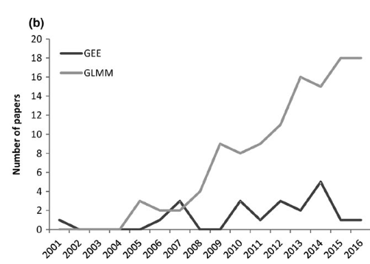

“Os métodos estatísticos tradicionais são baseados na suposição de que as observações em uma amostra são independentes umas das outras, ou seja, o valor de uma observação não é influenciado pelo valor de outra.

Essa suposição de independência é violada se os dados são agrupados (*clustered*), ou seja, se as observações em um agrupamento tenderem a ser mais semelhantes entre si do que com os indivíduos do restante da amostra.

Os dados agrupados surgem de três maneiras principais:

1. *Medidas repetidas em estudos longitudinais*: Neste caso os clusters são os sujeitos; observações repetidas sobre o mesmo sujeito serão mais semelhantes entre si do que observações sobre outros sujeitos.

Por exemplo:

- em estudos de asma ou outras doenças crônicas, os episódios da doença podem ocorrer em mais de uma ocasião no mesmo sujeito;
- em estudos longitudinais de doenças comuns da infância em países em desenvolvimento, as crianças podem apresentar vários episódios de diarreia, malária ou infecções respiratórias agudas durante o estudo;
- em um estudo de doenças cardiovasculares e obesidade, as medições da pressão arterial, índice de massa corporal e níveis de colesterol podem ser repetidas a cada 3 meses.
2. *Várias medidas sobre o mesmo sujeito*: Por exemplo, em pesquisas odontológicas são feitas observações em mais de um dente no mesmo sujeito. Neste caso, os agrupamentos (*clusters*) são novamente os sujeitos.
3. *Estudos em que os sujeitos são agrupados*: Isso ocorre, por exemplo, em:
- *ensaios randomizados em cluster*, nos quais grupos, em vez de indivíduos, são randomizados para receber as diferentes intervenções em estudo. Por exemplo, a unidade de randomização pode ser prática geral (https://en.wikipedia.org/wiki/General_practice), com todos os pacientes registrados em uma prática recebendo a mesma intervenção. Como os pacientes em uma prática geral podem ser mais semelhantes entre si do que com pacientes em outras práticas gerais, por exemplo, porque algumas áreas tendem a ser mais carentes do que outras ou devido à exposição a um risco ambiental comum, os dados são agrupados. Neste caso o cluster é o grupo de pacientes cadastrados na prática geral;
- *estudos de família*, uma vez que indivíduos de uma mesma família tendem a ser mais semelhantes entre si do que indivíduos de famílias diferentes, pois compartilham genes e ambiente semelhantes. Neste caso o cluster é a família;
- pesquisas em que a *amostragem por conglomerados* é empregada. Por exemplo, para estimar a porcentagem de jovens de 14 anos em Londres que trabalham nos fins de semana, podemos selecionar 1.000 crianças por amostragem aleatória de 20 escolas de todas as escolas de Londres e, em seguida, amostrar aleatoriamente 50 crianças de cada uma das escolas selecionadas. Como as crianças de uma escola podem ser mais parecidas entre si do que as crianças de escolas diferentes, os dados são agrupados. Neste caso, os clusters são as escolas.

É essencial que a presença de agrupamento seja permitida nas análises estatísticas.

A principal razão para isso, como veremos, é que os erros padrão podem ser muito pequenos se não levarem em conta o agrupamento nos dados.

Isso levará a intervalos de confiança muito estreitos e valores P muito pequenos.

Discutiremos quatro maneiras apropriadas de analisar dados agrupados:

1. calcular medidas de resumo para cada cluster e analisar essas medidas de resumo usando métodos-padrão;
2. usar erros-padrão robustos para corrigir erros-padrão para o agrupamento;
3. utilizar modelos de efeitos aleatórios (GLMM) que modelam explicitamente a similaridade entre indivíduos de um mesmo cluster;
4. usar equações de estimação generalizadas (GEE) que ajustam tanto os erros-padrão quanto as estimativas de parâmetros para permitir o agrupamento.”

> Kirkwood & Sterne, 2003, p. 355-6

“RESUMO DAS ABORDAGENS PARA A ANÁLISE DE DADOS AGRUPADOS

1. Se os dados estiverem agrupados, é essencial que o agrupamento seja permitido nas análises. Em particular, a falha em permitir o agrupamento pode significar que os erros-padrão das estimativas dos parâmetros são muito pequenos, de modo que os intervalos de confiança são muito estreitos e os valores *p* são muito pequenos.
2. É sempre válido derivar medidas-resumo para cada agrupamento e depois analisá-las usando métodos-padrão.
3. O provável efeito do agrupamento nos erros-padrão pode ser avaliado pela especificação de erros-padrão robustos que permitem o agrupamento. As estimativas de parâmetros não são afetadas. Para que esses erros-padrão robustos sejam confiáveis, precisamos de um número razoável de agrupamentos (pelo menos 30). Testes de Wald, em vez de testes de razão de verossimilhança (LR), devem ser usados.
4. Os modelos de efeitos aleatórios (multinível), GLMM, permitem a presença de agrupamento modificando o preditor linear por uma quantidade constante no agrupamento. Supõe-se que os efeitos aleatórios variem aleatoriamente entre os agrupamentos. Modelos de efeitos aleatórios funcionam bem para desfechos normalmente distribuídos e regressão de Poisson, mas a estimativa de modelos logísticos de efeitos aleatórios é difícil e computacionalmente exigente.
5. Equações de estimação generalizadas (GEE) modificam tanto as estimativas de parâmetros quanto os erros-padrão para permitir o agrupamento. Novamente, deve haver um número razoável de agrupamentos A abordagem GEE é particularmente útil em análises de regressão logística e quando o foco de interesse está no efeito de exposição estimado e onde o agrupamento não tem interesse intrínseco.”

> Kirkwood & Sterne, 2003, p. 369-70

# Análise de medidas repetidas

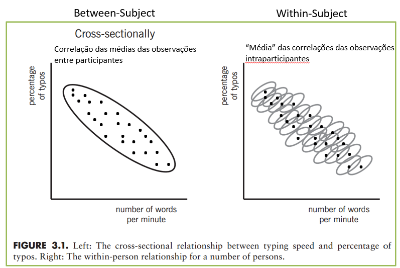

Hamaker, 2013, in Mehl & Conner, p. 43-61.

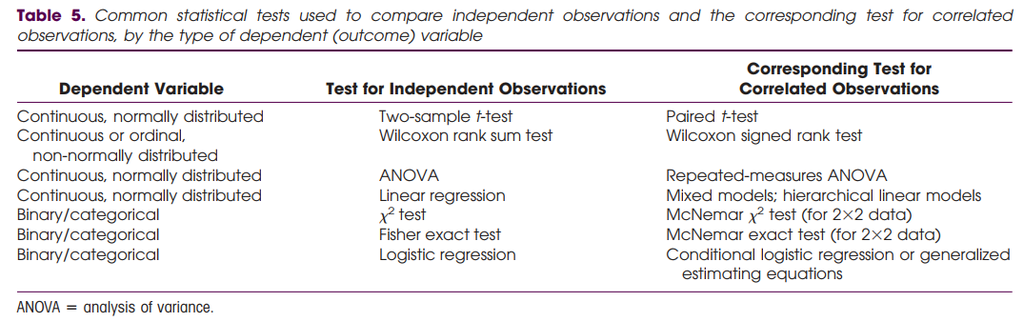

Sainani, 2010, p. 861.

# Formato de arquivo de dados

Largo (*wide*)

- Cada linha do arquivo corresponde a uma unidade experimental distinta

Longo (*long*)

- Cada linha do arquivo corresponde a cada observação da VD de cada unidade experimental distinta.

O formato do arquivo de dados para análise estatística por meio do Modelo Linear Geral (GLM) é o largo.

O formato longo é usado para análises com Modelo Linear Misto Generalizado (GLMM) e Equações de Estimação Generalizadas (GEE).

# Análise de correlação com dados agrupados

O coeficiente de correlação de Pearson avalia o grau de linearidade entre duas variáveis intervalares num delineamento entre participantes. A correlação de Pearson varia de -1 a 1, não depende do tamanho da amostra e é adimensional: [Wikipedia: Pearson correlation coefficient](https://en.wikipedia.org/wiki/Pearson_correlation_coefficient)

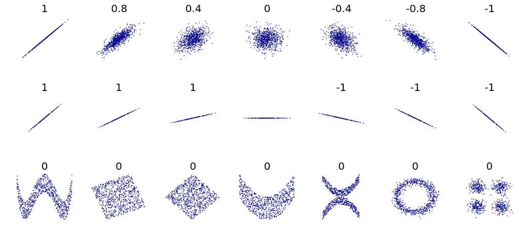

https://en.wikipedia.org/wiki/Pearson_correlation_coefficient#/media/File:Correlation_examples2.svg

# Correlação intra: pHi & PaCO2

Disóxia tecidual e a hipóxia são os maiores fatores determinantes do surgimento e propagação da falência de múltiplos órgãos em pacientes críticos.

- A disóxia tecidual ocorre quando há uma quantidade insuficiente de oxigênio disponível nos tecidos do corpo, apesar de haver uma quantidade adequada de oxigênio no sangue arterial. Esse fenômeno difere da hipóxia, que se refere à deficiência de oxigênio no sangue. A disóxia pode ser causada por problemas na utilização do oxigênio pelas células, devido a disfunções metabólicas ou envenenamento por cianeto, que impede que as células utilizem o oxigênio presente.

A medida do pH intramural (pHi) ou pH intramucoso gástrico (pHim) reflete o balanço ácido-básico tecidual em uma das primeiras regiões do corpo a desenvolver disóxia no choque.

O objetivo é avaliar a associação entre pHi e PaCO<sub>2</sub> (pressão parcial de CO<sub>2</sub> no sangue arterial) (https://en.wikipedia.org/wiki/PCO2).

“Vários estudos clínicos demonstraram que a acidose intramucosa gástrica detectada por esse procedimento prevê um aumento da mortalidade de adultos gravemente doentes em unidades de terapia intensiva (UTI) médicas e cirúrgicas, e que é um melhor preditor de mortalidade por doença crítica do que outras medidas de entrega global de oxigênio e hemodinâmica sistêmica.”

> Baigorri et al., 1997

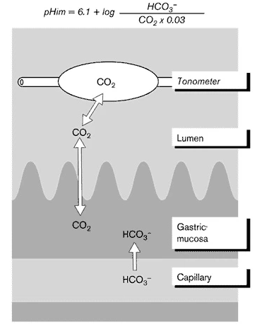

A tonometria gástrica determina o PaCO<sub>2</sub> intraluminal, que se presume estar em equilíbrio com o PaCO<sub>2</sub> na mucosa gástrica. O pHi pode ser calculado pela equação de Henderson-Hasselbalch, usando o valor de PaCO<sub>2</sub> determinado pela tonometria gástrica e a concentração de íon bicarbonato no sangue arterial.

> Baigorri et al., 1997

Os dados usados para testar esta associação estão em Bland & Altman (1995a).

# Análise descritiva de correlação intraparticipantes

```r
alfa <- 0.05

Dados <- rmcorr::bland1995
Dados$Subject <- factor(Dados$Subject)
print(Dados)
```

```
   Subject   pH PaCO2
1        1 6.68  3.97
2        1 6.53  4.12
3        1 6.43  4.09
4        1 6.33  3.97
5        2 6.85  5.27
6        2 7.06  5.37
7        2 7.13  5.41
8        2 7.17  5.44
9        3 7.40  5.67
10       3 7.42  3.64
11       3 7.41  4.32
12       3 7.37  4.73
13       3 7.34  4.96
14       3 7.35  5.04
```

[output cut: 33 more lines]

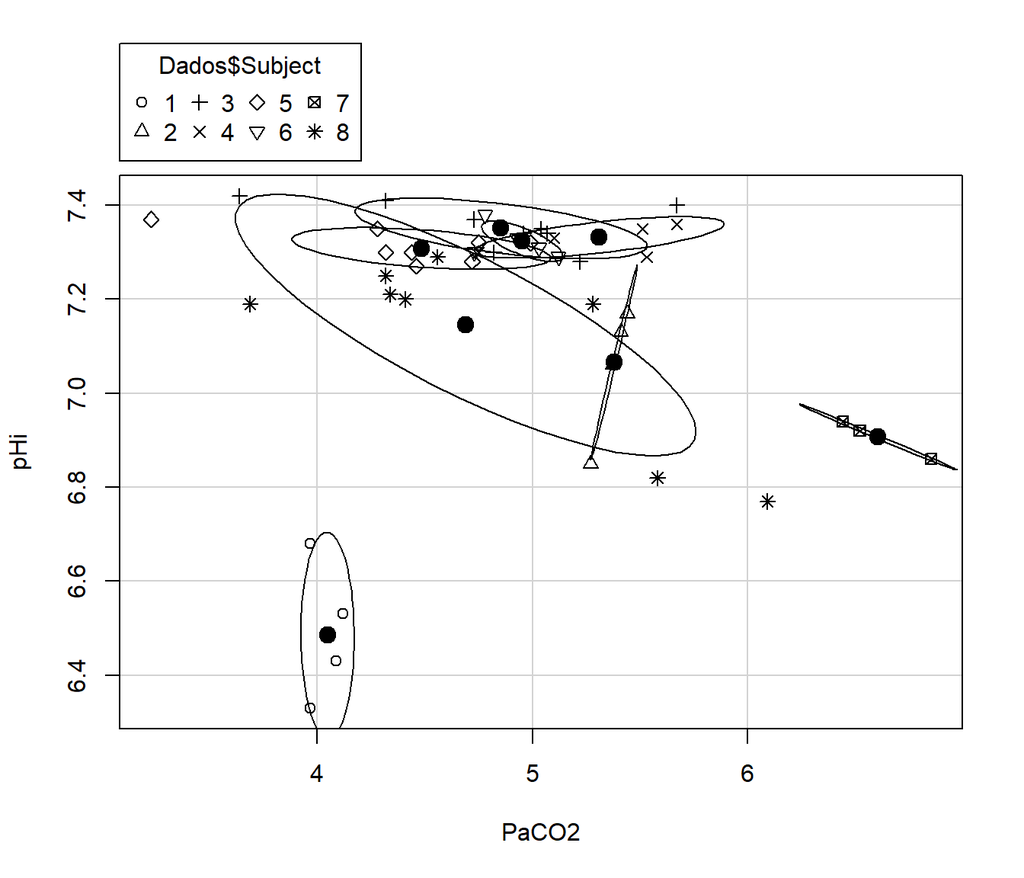

```r
car::scatterplot(Dados$PaCO2,
                 Dados$pH,
                 groups=Dados$Subject,
                 regLine=FALSE, smooth=FALSE,
                 ellipse=list(levels=c(.68),
                              robust=TRUE,
                              fill=FALSE),
                 col="black", xlab="PaCO2", ylab="pHi")
```

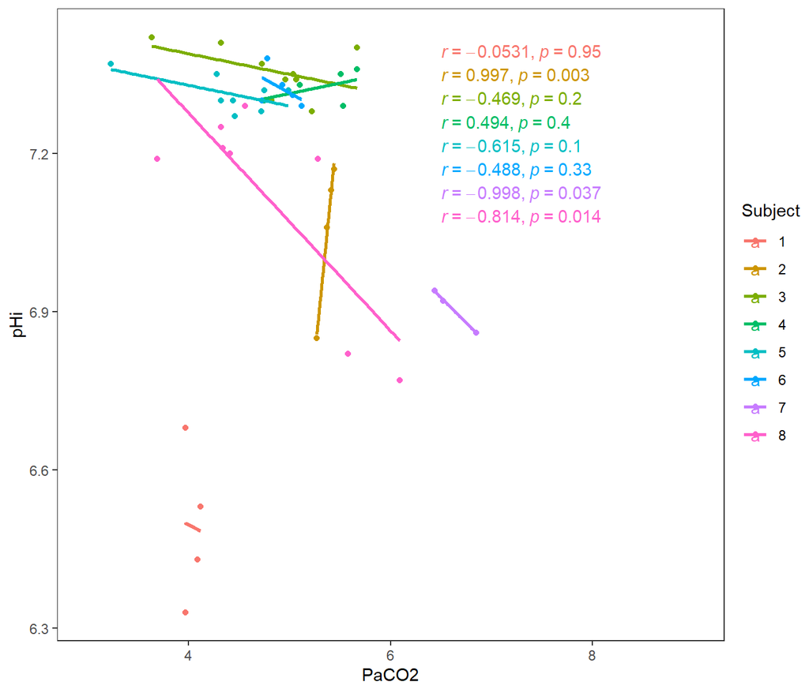

```r
Dados %>%
  ggplot2::ggplot(ggplot2::aes(x=PaCO2, y=pH,
                               color=Subject)) +
  ggplot2::geom_point() +
  ggplot2::geom_smooth(method="lm", formula=y~x, se=FALSE) +
  ggpubr::stat_cor(method="pearson", cor.coef.name="r",
                   na.rm=TRUE, r.digits=3, p.digits=2,
                   label.x=6.5) +
  ggplot2::labs(x="PaCO2", y="pHi") +
  ggplot2::xlim(3,9) +
  ggplot2::theme_test()
```

# Correlação intraparticipantes por `cor.test`: incorreta

```r
print(cor.test(Dados$PaCO2, Dados$pH))
```

```
    Pearson's product-moment correlation

data:  Dados$PaCO2 and Dados$pH
t = -0.43843, df = 45, p-value = 0.6632
alternative hypothesis: true correlation is not equal to 0
95 percent confidence interval:
 -0.3459063  0.2261851
sample estimates:
        cor
-0.06521774
```

Para um delineamento intraparticipantes, é possível estimar e testar a o coeficiente de correlação de Pearson implícito entre duas variáveis intervalares. Esta correlação implícita intraparticipantes nao é: (i) a média aritmética das correlações dos participantes; (ii) a média ponderada das correlações dos participantes. Bland & Altman (1995a) mostraram a maneira correta de estimar a correlação intra.

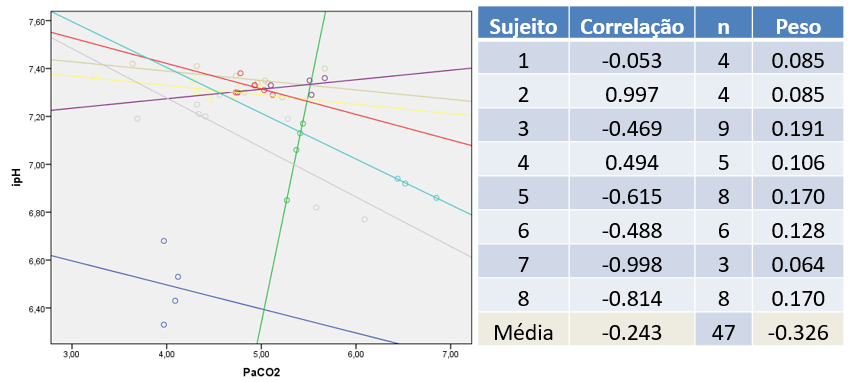

Bland & Altman, 1995a

# IC95% por *bootstrapping* das correlações intraparticipantes

```r
boot_corr <- Dados %>%
  tidyr::nest(data=-c(Subject)) %>% # grouping the Subject
  dplyr::mutate(boots=purrr::map(data,
                     ~rsample::bootstraps(.x, times=1e2,
                                          apparent=FALSE))) %>%
  tidyr::unnest(boots) %>% dplyr::mutate(correlations=purrr::map(splits,                                              ~rstatix::cor_test(PaCO2,                                                                 pH,                                                  data=rsample::analysis((.)))))
corr <- boot_corr %>%
  tidyr::unnest(correlations) %>% # unnesting tidied data frames
  dplyr::select(-data, -splits, -id)
corr <- IDPmisc::NaRV.omit(corr)

# bootstrap confidence interval
point <- Dados %>%
  dplyr::group_by(Subject) %>%
  rstatix::cor_test(PaCO2, pH, method="pearson")
CI <- corr %>%
  dplyr::group_by(Subject) %>%
  dplyr::summarise(lwr_CI=quantile(cor, alfa/2),
            .estimate=median(cor),
            upr_CI=quantile(cor, 1-alfa/2))
print(CI)
```

```
# A tibble: 7 × 4
  Subject lwr_CI .estimate upr_CI
  <fct>    <dbl>     <dbl>  <dbl>
1 1       -0.88     -0.053 0.96
2 2        1         1     1
3 3       -0.93     -0.46  0.618
4 4       -0.463     0.385 1
5 5       -0.88     -0.655 0.692
6 6       -1        -0.395 0.5
7 8       -0.985    -0.84  0.0260
```

# Correlação intraparticipantes por *bootstrapping*: correta

A estimativa do valor absoluto da correlação de Pearson para medidas repetidas é a raiz quadrada do eta parcial ao quadrado de PaCO2.

O sinal da correlação é obtido por meio do sinal da estimativa do parâmetro beta da regressão entre PaCO2 e pH intramural controlada pelo fator Subject.

```r
# Bland & Altman, 1995a
print(rmcorr::rmcorr(participant=Subject,
                     measure1=PaCO2,
                     measure2=pH,
                     dataset=Dados,
                     CI.level=1-alfa,
                     CIs="bootstrap",
                     nreps=1e4), digits=4)
```

```
Repeated measures correlation

r
-0.5067697

degrees of freedom
38

p-value
0.0008471081

95% confidence interval
-0.7294242 -0.07270856
```

```r
# 95% confidence interval (analytic)  = -0.7112297 -0.223255
# 95% confidence interval (bootstrap) = -0.727479  -0.06999879
```

# Medida média: “entre participantes”

```r
Dados.media <- aggregate(Dados, x=cbind(PaCO2, pH)~Subject, FUN=mean)
Dados.n <- aggregate(Dados, x=cbind(Subject)~Subject, FUN=length)
Dados.media <- cbind(Dados.media,Dados.n[,2])
names(Dados.media) <- c(names(Dados.media)[1:(length(names(Dados.media))-1)],
                        "Number")
names(Dados.media) <- c("Subject", "PaCO2.mean", "pH.mean", "Number")
print(Dados.media, digits=4)
```

```
  Subject PaCO2.mean pH.mean Number
1       1      4.037   6.492      4
2       2      5.373   7.053      4
3       3      4.830   7.357      9
4       4      5.312   7.326      5
5       5      4.399   7.314      8
6       6      4.920   7.323      6
7       7      6.603   6.907      3
8       8      4.784   7.115      8
```

# Correlação “entre participantes” por `cor.test`: incorreta

```r
print(cor.test(Dados.media$PaCO2.mean, Dados.media$pH.mean))
```

```
    Pearson's product-moment correlation

data:  Dados.media$PaCO2.mean and Dados.media$pH.mean
t = 0.20098, df = 6, p-value = 0.8474
alternative hypothesis: true correlation is not equal to 0
95 percent confidence interval:
 -0.6609881  0.7435975
sample estimates:
       cor
0.08177314
```

# Correlacao “entre participantes” por `weights::wtd.cor`: correta

```r
# Bland & Altman 1995b: analitica e boostrapping
print(weights::wtd.cor(Dados.media$PaCO2.mean,
                       Dados.media$pH.mean,
                       weight=Dados.media$Number,
                       bootp=TRUE, bootse=TRUE, bootn=1e4), digits=4)
```

```
  correlation   bootcor std.err   t.value p.value
Y     0.06976 -0.001752  0.5871 -0.002984  0.8962
```

# Desenhando as correlações intra e entre participantes

## Within correlation

`r = -0.51`

degrees of freedom = 38

p-value = 0.00085

95% confidence interval (analytic) = -0.71 -0.22

95% confidence interval (bootstrap) = -0.73 -0.07

## Between correlation

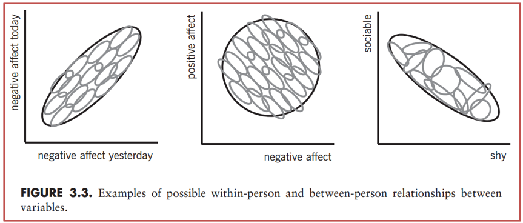

Hamaker, 2013, in Mehl & Conner, p. 43-61.

# rcGLM: robust clustered General Linear Model

“Dada esta revisão da literatura e nossas novas simulações, achamos que a maioria dos pesquisadores pode continuar usando confortavelmente o software OLS padrão, de preferência com os erros-padrão robustos, em vez de mudar para os métodos semiparamétricos mais recentes.”

> Judkins DR & Porter KE, 2016

“`estimatr` is a package in R dedicated to providing fast estimators that take into consideration designs often used by social scientists.

Estimators are statistical methods for estimating quantities of interest like treatment effects or regression parameters.

Many of the estimators included with the R programming language or popular R packages are slow and have default settings that lead to statistically inappropriate estimates.

Certain estimators that reflect cutting-edge advances in statistics are not yet implemented in R packages for convenient use.

`estimatr` is designed to solve these problems and provide estimators tuned for design-based inference.”

The current estimators we provide are:

- `lm_robust`: for fitting linear models with heteroskedasticity/cluster-robust standard errors
- `lm_lin`: a wrapper for lm_robust() to simplify interacting centered pre-treatment covariates with a treatment variable
- `iv_robust`: two stage least squares estimation of instrumental variables regression
- `difference_in_means`: for estimating differences in means with appropriate standard errors for unit-randomized, cluster-randomized, block-randomized, matched-pair randomized, and matched-pair clustered designs
- `horvitz_thompson`: for estimating average treatment effects taking into consideration treatment probabilities or sampling probabilities for simple and cluster randomized designs

> Sonnet, ?

# Regressão linear ponderada: `estimatr::lm_robust`

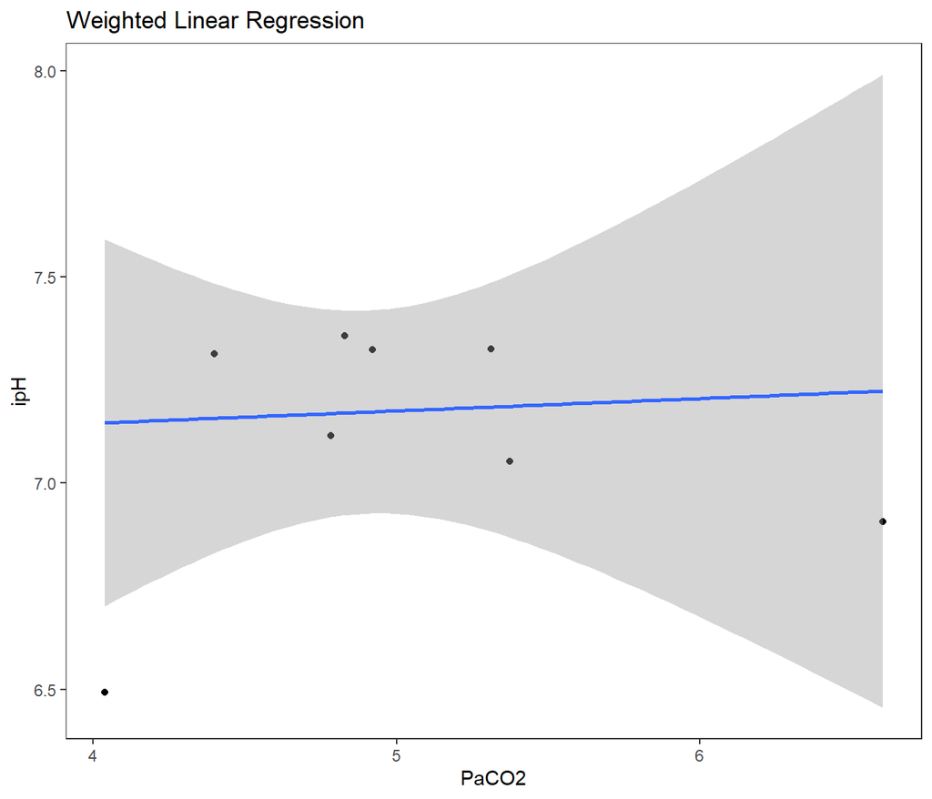

```r
Dados.media %>%
  ggplot2::ggplot(ggplot2::aes(x=PaCO2.mean, y=pH.mean)) +
  ggplot2::geom_point() +
  ggplot2::stat_smooth(method="lm", formula=y~x, se=TRUE,
                       ggplot2::aes(weight=Number)) +
  ggplot2::labs(x="PaCO2", y="ipH",
                title="Weighted Linear Regression") +
  ggplot2::theme_test()
```